# Patient activation (PAM-13) in adults with chronic disease

Dataset 9: Patient activation for self-management in chronic disease

RSR feasibility analysis

2026-08-03

# Introduction

The Patient Activation Measure (PAM-13) captures how far a patient has the knowledge, skills and confidence to manage their own long-term condition. These data come from a cross-sectional survey of 1,154 Dutch adults treated in primary and secondary care for type 2 diabetes, COPD, chronic heart failure or chronic renal disease (Bos-Touwen et al., *PLoS ONE* 2015;10(5):e0126400). Activation matters because self-management support programmes are increasingly targeted at patients on the basis of how activated they already are, so it is useful to know which patient characteristics mark out the least activated.

**Aim.** Among Dutch adults with one of four chronic conditions, we examined which of age, sex, education, index disease, comorbidity burden, illness perceptions and perceived social support are independently associated with PAM-13 score, mutually adjusting for the others.

This is a *Purpose 3* analysis: several predictors are of interest and the question is which remain associated with the outcome after mutual adjustment.

# Methods

**Data source.** Cross-sectional postal and online survey of adults with type 2 diabetes, COPD, chronic heart failure or chronic renal disease recruited from Dutch general practices and hospital outpatient clinics; 1154 participants with complete PAM-13 data. All measurements were taken at a single occasion.

**Variables.** The outcome is `pam_score`, the PAM-13 total score on a 0-100 scale, where higher scores mean greater ability and confidence to self-manage. Predictors are `age_yrs` (years), `sex` (reference: male), `education_level` (lower / middle / higher, reference: lower, the largest group), `disease` (reference: type 2 diabetes, the largest group), `charlson_index` (Charlson comorbidity index, points; higher = more comorbidity), `ipq_total` (Brief Illness Perception Questionnaire total, 0-80; higher = a more threatening view of one’s illness) and `social_support_total` (Multidimensional Scale of Perceived Social Support total, 12-84; higher = more perceived support).

`pam_level` is a deterministic banding of `pam_score` itself and is therefore never used as a predictor here. `bmi` in this file is exactly `weight_kg / (height_cm/100)^2`, so at most one of those three would ever enter a model; none is used here because body size has no clear prior link to activation. `n_comorbidities` correlates 0.78 with `charlson_index`, so only the Charlson index is used.

**Statistical analysis.** Linear regression (`lm()`), justified because the outcome is continuous and roughly symmetric. We fitted a univariable model for each predictor first, then a single multivariable model containing all of them. Predictors were chosen in advance on subject-matter grounds, not by significance. Significance threshold 0.05; estimates are reported with 95% confidence intervals. Assumptions were checked with `performance::check_model()`. Analysis used R version 4.6.0 (2026-04-24) with tidyverse, gtsummary and performance.

**Missing data.** Complete-case analysis: 1087 of 1154 rows were analysed (67 dropped). Missing questionnaire answers were coded 99 in the original deposit, but that conversion to `NA` has already been applied in this CSV; a check across all numeric columns other than `id` found 0 remaining values equal to 99, so no further re-coding was needed.

# Results

## Sample characteristics

**Table 1. Sample characteristics.**

| **Characteristic** | **N** | **N = 1,087**<sup>1</sup> |
| --- | --- | --- |
| pam_score | 1,087 | 53 (45, 60) |
| age_yrs | 1,087 | 70 (62, 78) |
| sex | 1,087 |  |
| Male |  | 663 (61%) |
| Female |  | 424 (39%) |
| education_level | 1,087 |  |
| Lower |  | 514 (47%) |
| Middle |  | 411 (38%) |
| Higher |  | 162 (15%) |
| disease | 1,087 |  |
| Type 2 diabetes |  | 399 (37%) |
| COPD |  | 278 (26%) |
| Heart failure |  | 210 (19%) |
| Renal disease |  | 200 (18%) |
| charlson_index | 1,087 | 3.00 (1.00, 4.00) |
| ipq_total | 1,087 | 38 (27, 45) |
| social_support_total | 1,087 | 66 (54, 75) |

<sup>1</sup> Median (Q1, Q3); n (%)

The analysed sample is elderly (median age around 70) and predominantly male, with a median Charlson index of 3 and mostly lower or middle education. The median PAM-13 score sits near 53, which is at the boundary between activation levels 2 and 3, so a large share of this sample is in the lower half of the activation range.

## Exploratory figure

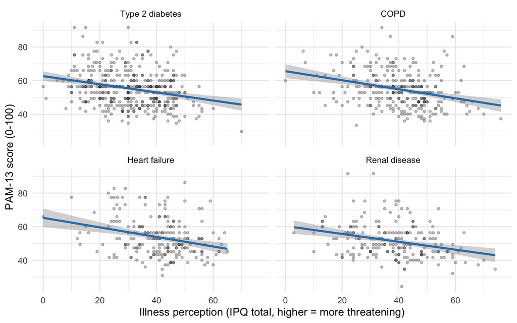

Figure 1. PAM-13 score against illness-perception score, by index disease. Lines are linear smooths with 95% confidence bands.

Patients who see their illness as more threatening report lower activation, and the slope looks broadly similar in all four disease groups, so a single common slope for `ipq_total` is a reasonable simplification.

## Univariable models

| **Characteristic** | **N** | **Beta** | **95% CI** | **p-value** |
| --- | --- | --- | --- | --- |
| age_yrs | 1,087 | -0.07 | -0.13, -0.01 | 0.023 |
| sex | 1,087 |  |  |  |
| Male |  | — | — |  |
| Female |  | -0.88 | -2.2, 0.43 | 0.2 |
| education_level | 1,087 |  |  |  |
| Lower |  | — | — |  |
| Middle |  | 0.28 | -1.1, 1.7 | 0.7 |
| Higher |  | 4.2 | 2.3, 6.1 | <0.001 |
| disease | 1,087 |  |  |  |
| Type 2 diabetes |  | — | — |  |
| COPD |  | -0.43 | -2.1, 1.2 | 0.6 |
| Heart failure |  | -1.5 | -3.3, 0.29 | 0.10 |
| Renal disease |  | -3.8 | -5.6, -1.9 | <0.001 |
| charlson_index | 1,087 | -0.79 | -1.1, -0.44 | <0.001 |
| ipq_total | 1,087 | -0.24 | -0.29, -0.19 | <0.001 |
| social_support_total | 1,087 | 0.13 | 0.09, 0.17 | <0.001 |

Abbreviation: CI = Confidence Interval

Illness perception is the strongest crude predictor: each additional point on the IPQ total is associated with a 0.24-point lower PAM-13 score (95% CI -0.29 to -0.19, p < 0.001), so a 20-point difference in illness perception corresponds to roughly 4.8 PAM points. Perceived social support runs the other way (+0.13 PAM points per point of support, p < 0.001), higher education is associated with a 4.2-point advantage over lower education (p < 0.001), and both age (-0.07 per year, p = 0.024) and the Charlson index (-0.79 per point, p < 0.001) are associated with lower activation. Crudely, renal disease patients score 3.8 points below the diabetes group (p < 0.001).

## Why adjustment is needed

The crude associations mix several patient characteristics that travel together in this sample. `charlson_index` is one clear confounder: it rises with `age_yrs` (r = 0.34) and is itself associated with lower activation, so part of the crude age effect is really comorbidity burden, and part of the crude Charlson effect is really age. `disease` is a second: the four groups differ substantially in age, sex mix and comorbidity — the renal disease group in particular is older and more comorbid — so the crude renal-disease deficit in activation partly reflects who ends up in that group rather than the condition itself. `education_level` is a third: education is associated with both illness perceptions (better-educated patients report less threatening views of their illness) and with activation, so the crude IPQ slope is partly an education effect. Because the four disease groups were pooled by design, adjusting for `disease` is not optional here — it is what makes the other coefficients interpretable as within-disease comparisons.

## Multivariable model

| **Characteristic** | **Beta** | **95% CI** | **p-value** |
| --- | --- | --- | --- |
| age_yrs | -0.03 | -0.09, 0.03 | 0.3 |
| sex |  |  |  |
| Male | — | — |  |
| Female | -0.36 | -1.6, 0.90 | 0.6 |
| education_level |  |  |  |
| Lower | — | — |  |
| Middle | 0.00 | -1.3, 1.3 | >0.9 |
| Higher | 2.8 | 0.97, 4.6 | 0.003 |
| disease |  |  |  |
| Type 2 diabetes | — | — |  |
| COPD | 2.0 | 0.36, 3.6 | 0.017 |
| Heart failure | 1.2 | -0.65, 3.1 | 0.2 |
| Renal disease | -1.3 | -3.2, 0.56 | 0.2 |
| charlson_index | -0.41 | -0.80, -0.02 | 0.037 |
| ipq_total | -0.22 | -0.27, -0.17 | <0.001 |
| social_support_total | 0.11 | 0.07, 0.15 | <0.001 |

Abbreviation: CI = Confidence Interval

Model fit

| Statistic | Value |
| --- | --- |
| R-squared | 0.137 |
| Adjusted R-squared | 0.129 |
| Residual SE | 10.050 |
| N | 1087.000 |
| Model df | 10.000 |

Adjusting for all seven predictors, illness perception remains the dominant association: conditional on age, sex, education, disease, comorbidity and social support, each extra IPQ point is associated with a 0.22-point lower PAM score (95% CI -0.27 to -0.17, p < 0.001). Perceived social support remains independently associated in the opposite direction (+0.11 per point, 95% CI 0.07 to 0.15, p < 0.001), and higher education retains a 2.8-point advantage over lower education (95% CI 0.97 to 4.64, p = 0.003). The Charlson index is now only weakly associated (-0.41 per point, 95% CI -0.80 to -0.02, p = 0.037) and age is no longer associated at all (p = 0.29). The model explains R² = 0.137 of the variance in PAM score (adjusted R² = 0.129), which is modest: most of what drives activation in this sample is not captured by these variables.

## Unadjusted versus adjusted

**Table 2. Unadjusted and adjusted estimates.**

| **Characteristic** | **Unadjusted** **N** | **Unadjusted** **Beta** | **Unadjusted** **95% CI** | **Unadjusted** **p-value** | **Adjusted** **Beta** | **Adjusted** **95% CI** | **Adjusted** **p-value** |
| --- | --- | --- | --- | --- | --- | --- | --- |
| age_yrs | 1,087 | -0.07 | -0.13, -0.01 | 0.023 | -0.03 | -0.09, 0.03 | 0.3 |
| sex | 1,087 |  |  |  |  |  |  |
| Male |  | — | — |  | — | — |  |
| Female |  | -0.88 | -2.2, 0.43 | 0.2 | -0.36 | -1.6, 0.90 | 0.6 |
| education_level | 1,087 |  |  |  |  |  |  |
| Lower |  | — | — |  | — | — |  |
| Middle |  | 0.28 | -1.1, 1.7 | 0.7 | 0.00 | -1.3, 1.3 | >0.9 |
| Higher |  | 4.2 | 2.3, 6.1 | <0.001 | 2.8 | 0.97, 4.6 | 0.003 |
| disease | 1,087 |  |  |  |  |  |  |
| Type 2 diabetes |  | — | — |  | — | — |  |
| COPD |  | -0.43 | -2.1, 1.2 | 0.6 | 2.0 | 0.36, 3.6 | 0.017 |
| Heart failure |  | -1.5 | -3.3, 0.29 | 0.10 | 1.2 | -0.65, 3.1 | 0.2 |
| Renal disease |  | -3.8 | -5.6, -1.9 | <0.001 | -1.3 | -3.2, 0.56 | 0.2 |
| charlson_index | 1,087 | -0.79 | -1.1, -0.44 | <0.001 | -0.41 | -0.80, -0.02 | 0.037 |
| ipq_total | 1,087 | -0.24 | -0.29, -0.19 | <0.001 | -0.22 | -0.27, -0.17 | <0.001 |
| social_support_total | 1,087 | 0.13 | 0.09, 0.17 | <0.001 | 0.11 | 0.07, 0.15 | <0.001 |

Abbreviation: CI = Confidence Interval

Three estimates move meaningfully. Age halves and loses significance (-0.067 to -0.032, p = 0.024 to p = 0.29): the crude age association was largely comorbidity, which age brings with it. The Charlson index also shrinks towards the null by about half (-0.79 to -0.41) but stays just significant, for the mirror-image reason plus overlap with disease group. Renal disease moves strongly towards the null (-3.77 to -1.33, p < 0.001 to p = 0.17), so the apparent activation deficit in renal patients is mostly explained by their older age, higher comorbidity and more threatening illness perceptions rather than by the diagnosis. COPD moves in the other direction, from a null crude estimate (-0.43, p = 0.60) to a positive adjusted one (+1.98, p = 0.017): once the heavier illness-perception burden of COPD patients is held constant, they look slightly *more* activated than diabetes patients — a suppression effect worth flagging rather than over-interpreting. Social support and illness perception barely move (0.127 to 0.110; -0.241 to -0.223), which tells us those two are not simply standing in for the demographic and clinical variables. Education attenuates from +4.2 to +2.8 but keeps its significance.

## Diagnostics

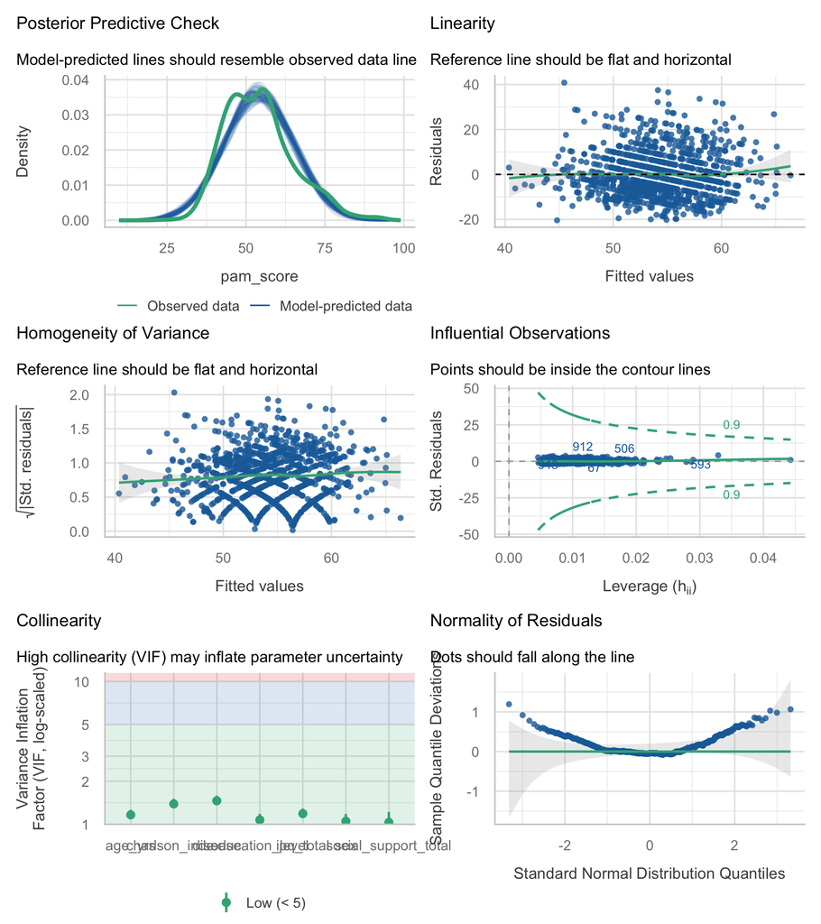

```
## OK: Error variance appears to be homoscedastic (p = 0.093).
```

| Term | VIF | VIF_CI_low | VIF_CI_high | SE_factor | Tolerance | Tolerance_CI_low | Tolerance_CI_high |
| --- | --- | --- | --- | --- | --- | --- | --- |
| age_yrs | 1.164404 | 1.102289 | 1.264240 | 1.079076 | 0.8588083 | 0.7909891 | 0.9072034 |
| sex | 1.051261 | 1.014501 | 1.181213 | 1.025310 | 0.9512386 | 0.8465876 | 0.9857067 |
| education_level | 1.073817 | 1.029631 | 1.183894 | 1.017964 | 0.9312576 | 0.8446705 | 0.9712219 |
| disease | 1.461140 | 1.361032 | 1.589007 | 1.065243 | 0.6843969 | 0.6293238 | 0.7347365 |
| charlson_index | 1.389307 | 1.297716 | 1.509075 | 1.178688 | 0.7197835 | 0.6626577 | 0.7705847 |
| ipq_total | 1.187846 | 1.122199 | 1.288757 | 1.089883 | 0.8418603 | 0.7759414 | 0.8911072 |
| social_support_total | 1.032492 | 1.004743 | 1.222588 | 1.016116 | 0.9685303 | 0.8179371 | 0.9952793 |

Linearity and the posterior-predictive panel look acceptable: the fitted-versus- residual smooth is close to flat, and simulated data track the observed PAM distribution. Homogeneity of variance passes (`check_heteroscedasticity()` p = 0.093), so ordinary standard errors are reported and no robust-SE re-estimation was needed. Normality of residuals is formally rejected (p < 0.001) — the PAM distribution is slightly lumpy because the PAM-13 has a finite set of achievable scores — but the departure is mild in the Q-Q plot and, with n over 1,000, it has little practical effect on the confidence intervals. Collinearity is not a problem: all VIFs are below 1.5 (largest: `disease` 1.46, `charlson_index` 1.39). No observation exceeds the Cook’s distance threshold.

# Discussion

Among Dutch adults with one of four chronic conditions, how threatening a patient perceives their illness to be and how much social support they feel they have are the characteristics most strongly and independently associated with patient activation; higher education adds a further modest advantage. Age, sex and index disease add very little once these are accounted for. Practically, this points self-management support towards illness beliefs and the patient’s support network rather than towards demographic targeting — but the model explains only about 13% of the variance, so activation is far from predictable from routinely collected characteristics.

**Limitations.** The design is cross-sectional, so nothing here establishes direction: a patient who feels unable to manage their illness may well come to see it as more threatening, rather than the reverse, and the same circularity applies to social support. The file contains no disease-specific severity markers — no eGFR or dialysis status for renal disease, no NYHA class for heart failure, no GOLD stage for COPD — so “severity” is represented only by the generic Charlson index, and residual confounding by severity is likely, especially for the `disease` coefficients. `ipq_total` and `pam_score` are both self-reported on the same questionnaire occasion, so common-method bias will inflate their association. Residual normality is formally violated. Complete- case analysis dropped 67 participants (5.8%), and if those with missing questionnaire items are less activated the estimates are mildly optimistic. All estimates are associations, not effects.

**Future work.** A longitudinal follow-up measuring illness perceptions and activation at two time points would separate the two directions of the IPQ-PAM association.

# Feasibility notes

*Not part of a student report.*

- **Works well.** This is the cleanest outcome in the dataset. `pam_score` has zero missing values, is continuous over a wide range (24.4-91.6), and has several genuinely different predictors with a mix of significant and non-significant results — good teaching material for Purpose 3.
- **Complete-case N = 1087** of 1154 (67 dropped, 5.8%). Losses come from the questionnaire scales, not the outcome.
- **No collinearity problem**: max VIF 1.46. But two traps students will fall into are live in this file: (i) `pam_level` is a deterministic banding of `pam_score` and gives an R² of 0.87 on its own (0.89 as a factor) if used as a predictor;
  2. `charlson_index` and `n_comorbidities` correlate at r = 0.78 and should not both be entered.
- **Diagnostics**: homoscedasticity OK (p = 0.09), residual normality rejected (p < 0.001) but visually mild; no influential points. No robust SEs needed.
- **Weak R² (0.137)**: acceptable for a survey outcome, but students expecting a “strong model” will be disappointed. Worth telling them in advance.
- **Suppression effect on COPD** (crude null to positive adjusted) is a nice discussion point but confuses weaker students.